# Assignment 5 - DESeq2

For more detailed instructions, please read the assignment page in the course textbook.

Use this block to source your `main.R`.

```r
source('main.R')
```

[figure not shown]

[figure not shown]

## 1. Reading and subsetting the data from verse_counts.tsv and sample_metadata.csv

To begin, we will subset the counts matrix to only contain a subset of samples found in the original data. We have provided you with the *full* counts matrix of samples and a metadata file containing relevant experimental variables for each sample. These files are named ‘verse_counts.tsv’ and ‘sample_metadata.csv’, respectively. Define a function that reads from these two files to construct a counts matrix and matching sample dataframe containing only samples belonging to the vP0 and vAd timepoints. This should correspond to a total of 4 samples (vP0_1, vP0_2, vAd_1, ’vAd_2). Store this counts matrix and the sample dataframe in a SummarizedExperiments object. Ensure that the name of your counts matrix stored as an assay in the SummarizedExperiment object is `counts`.

```
## # A tibble: 55,416 x 9
##    gene                 vP0_1 vP0_2 vP4_1 vP4_2 vP7_1 vP7_2 vAd_1 vAd_2
##    <chr>                <dbl> <dbl> <dbl> <dbl> <dbl> <dbl> <dbl> <dbl>
##  1 ENSMUSG00000102693.2     0     0     0     0     0     0     0     0
##  2 ENSMUSG00000064842.3     0     0     0     0     0     0     0     0
##  3 ENSMUSG00000051951.6    19    24    17    17    17    12     7     5
##  4 ENSMUSG00000102851.2     0     0     0     0     1     0     0     0
##  5 ENSMUSG00000103377.2     1     0     0     1     0     1     1     0
##  6 ENSMUSG00000104017.2     0     3     0     0     0     1     0     0
##  7 ENSMUSG00000103025.2     0     0     0     0     0     0     0     0
##  8 ENSMUSG00000089699.2     0     0     0     0     0     0     0     0
##  9 ENSMUSG00000103201.2     0     0     0     0     0     0     0     1
## 10 ENSMUSG00000103147.2     0     0     0     0     0     0     0     0
## # ... with 55,406 more rows
```

```
## # A tibble: 8 x 8
##    ...1 geo_accession r1_name         r2_name r1_ftp r2_ftp samplename timepoint
##   <dbl> <chr>         <chr>           <chr>   <chr>  <chr>  <chr>      <chr>
## 1     0 SRR1727914    SRR1727914_1.f~ SRR172~ ftp:/~ ftp:/~ vP0_1      vP0
## 2     1 SRR1727915    SRR1727915_1.f~ SRR172~ ftp:/~ ftp:/~ vP0_2      vP0
## 3     2 SRR1727916    SRR1727916_1.f~ SRR172~ ftp:/~ ftp:/~ vP4_1      vP4
## 4     3 SRR1727917    SRR1727917_1.f~ SRR172~ ftp:/~ ftp:/~ vP4_2      vP4
## 5     4 SRR1727918    SRR1727918_1.f~ SRR172~ ftp:/~ ftp:/~ vP7_1      vP7
## 6     5 SRR1727919    SRR1727919_1.f~ SRR172~ ftp:/~ ftp:/~ vP7_2      vP7
## 7     6 SRR1727920    SRR1727920_1.f~ SRR172~ ftp:/~ ftp:/~ vAd_1      vAd
## 8     7 SRR1727921    SRR1727921_1.f~ SRR172~ ftp:/~ ftp:/~ vAd_2      vAd
```

Display the colData from your SummarizedExperiment object here:

```
## [1] "vP0_1" "vP0_2" "vAd_1" "vAd_2"
```

## 2. [Running DESeq2](http://bioconductor.org/packages/devel/bioc/vignettes/DESeq2/inst/doc/DESeq2.html#differential-expression-analysis)

DESeq2 has a built-in function that directly uses a SummarizedExperiment object. Define a function that takes your SummarizedExperiment and a design formula and runs DESeq2 with standard parameters. In our case, we wish to determine what genes are differentially expressed between our samples based on timepoint and our model will simply be `~ timepoint` and we will use `vP0` as our reference level.

Return a *list* containing both the results from DESeq2 as a dataframe as well as the DESeqDataSet object updated with various statistics in the course of the analysis (referred to as the dds in the vignette)

## 3. Annotating results to construct a labeled volcano plot

Using the results generated by DESeq2, convert it to a `tibble` and add one additional column that denotes whether a gene is either: 1. Upregulated and significant at a given padj threshold, 2.Downregulated and significant at a given padj threshold, or 3. Not significant at a given padj threshold. **Name this column `volc_plot_status`. Make sure the values for these labels are UP, DOWN, and NS, respectively.** Have your function take the DESeq2 results as well as a user-defined threshold for padj and set it at .10.

```
##     genes              baseMean        log2FoldChange       lfcSE
##  Length:55416       Min.   :     0.0   Min.   :-9.651   Min.   :0.135
##  Class :character   1st Qu.:     0.0   1st Qu.:-0.621   1st Qu.:0.257
##  Mode  :character   Median :     0.2   Median : 0.209   Median :1.114
##                     Mean   :   307.3   Mean   : 0.194   Mean   :1.906
##                     3rd Qu.:    17.5   3rd Qu.: 1.008   3rd Qu.:3.474
##                     Max.   :629265.5   Max.   :10.276   Max.   :4.994
##                                        NA's   :25475    NA's   :25475
##       stat             pvalue           padj       volc_plot_status
##  Min.   :-34.221   Min.   :0.000   Min.   :0.00    Length:55416
##  1st Qu.: -0.655   1st Qu.:0.042   1st Qu.:0.01    Class :character
##  Median :  0.187   Median :0.449   Median :0.26    Mode  :character
##  Mean   : -0.105   Mean   :0.433   Mean   :0.36
##  3rd Qu.:  0.803   3rd Qu.:0.747   3rd Qu.:0.70
##  Max.   : 37.201   Max.   :1.000   Max.   :1.00
##  NA's   :25475     NA's   :25475   NA's   :36564
```

### Captions for figures

```r
caption_4 <- 'This histogram represents the counts of the raw p-values for the genes discovered in the experiment.'
caption_5 <- 'This histogram represents the Log2FoldChange values for all significantly differentially expressed genes at a adjusted p-value threshold of 0.1.'
caption_6 <- 'Top ten differentially expressed genes are ranked by ascending adjusted p-value.'
caption_7 <- 'This volcano plot visualizes the differential expression results.'
caption_9 <- 'This plot represents the top ten positive and negative NES pathways.'
```

## 4. Diagnostic plot of the raw p-values for all genes

Using the same results tibble from the previous function, plot a histogram of the raw p-values for all of the genes discovered in the experiment. Avoid using the base ggplot2 theme and make sure to label any appropriate axes and components of the plot.

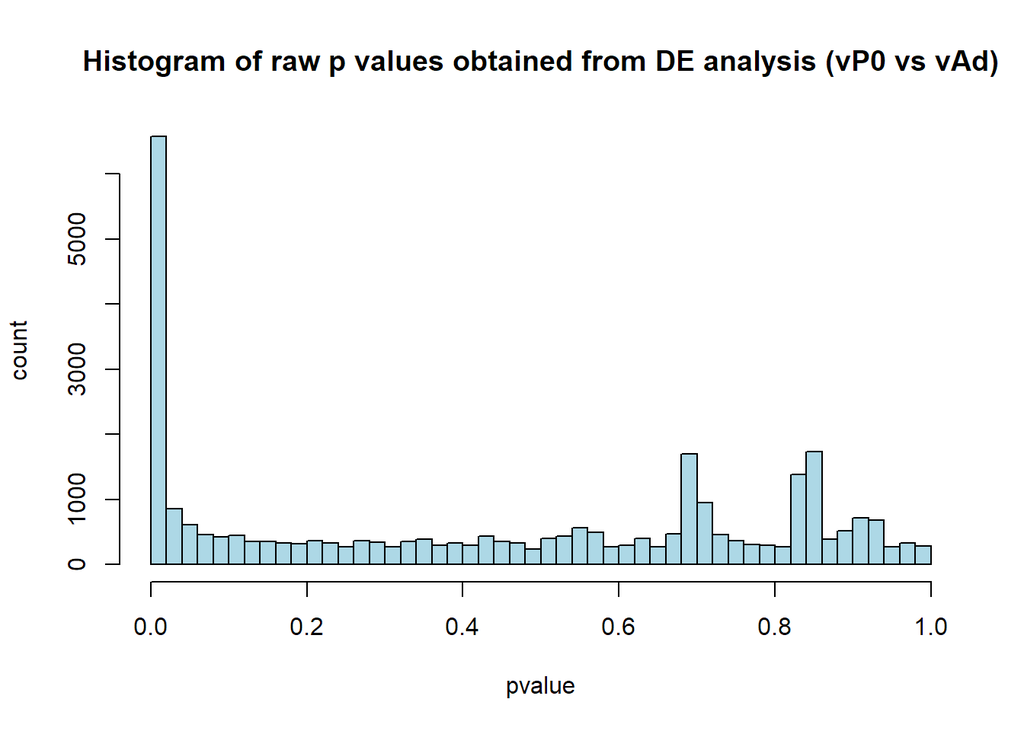

This histogram represents the counts of the raw p-values for the genes discovered in the experiment.

## 5. Plotting the LogFoldChanges for differentially expressed genes

Using the results tibble, make a histogram of the Log2FoldChange values for all significant differentially expressed genes at a user-defined padj threshold and set this threshold to .10. Avoid using the base ggplot2 theme and make sure to label any appropriate axes and components of the plot.

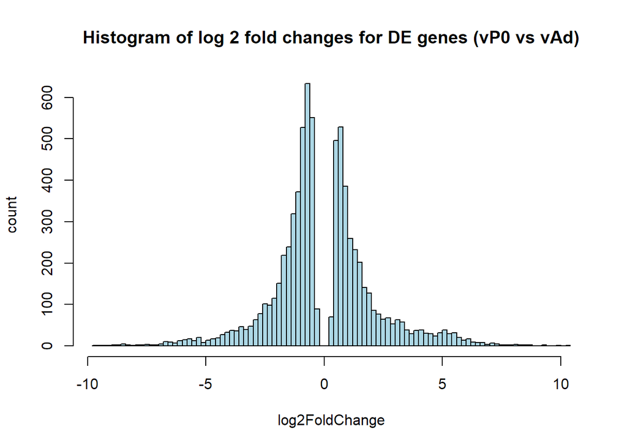

This histogram represents the Log2FoldChange values for all significantly differentially expressed genes at a adjusted p-value threshold of 0.1.

## 6. Plotting the normalized counts of differentially expressed genes

Extract out the DESeq2 normalized counts (by size factors) for the top ten differentially expressed genes as ranked by ascending padj. Make a scatter / jitter plot of the counts and label each by their samplenames.

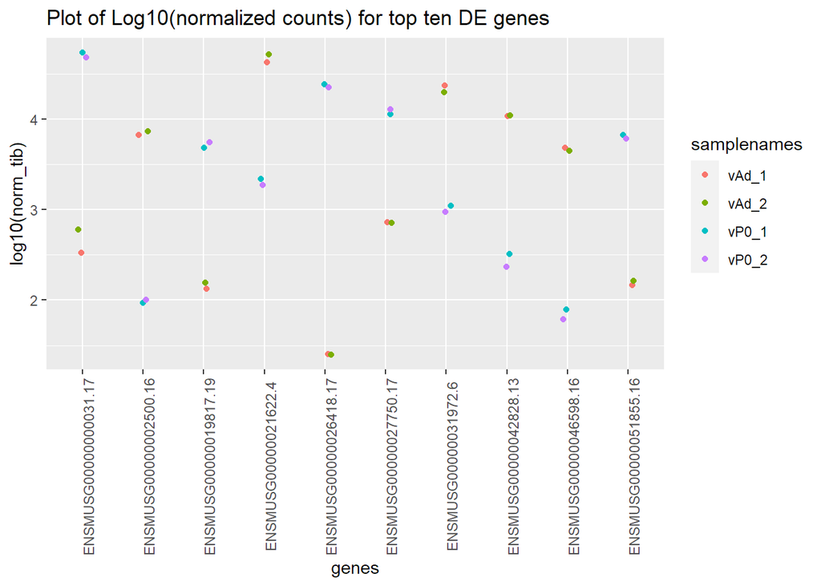

Top ten differentially expressed genes are ranked by ascending adjusted p-value.

## 7. Volcano Plot to visualize differential expression results

Using the status column you generated in part 3, make a volcano plot of the DESeq2 results and color the points appropriately.

[figure not shown]

This volcano plot visualizes the differential expression results.

## 8. Running fgsea

Perform a GSEA using a ranked list log2FoldChange values for all genes discovered in the DESeq2 results against the C2 Canonical Pathways gene set collection. Remember to convert the gene identifiers in our results to the appropriate matching format found in the C2 gene sets. fgsea expects a named vector of gene level statistics and the gene sets in the form of a named list. As recommended, please set the minSize and maxSize parameters to 15 and 500, respectively. Otherwise, run fgsea using default parameters and the `fgsea()` function.

```
## # A tibble: 1,981 x 8
##    pathway                    pval  padj log2err     ES    NES  size leadingEdge
##    <chr>                     <dbl> <dbl>   <dbl>  <dbl>  <dbl> <int> <list>
##  1 BIOCARTA_41BB_PATHWAY    0.896  1      0.0536 -0.258 -0.693    18 <chr [8]>
##  2 BIOCARTA_AGR_PATHWAY     0.924  1      0.0543 -0.224 -0.698    32 <chr [2]>
##  3 BIOCARTA_AKT_PATHWAY     0.499  0.847  0.0829 -0.347 -0.967    21 <chr [9]>
##  4 BIOCARTA_ALK_PATHWAY     0.243  0.562  0.114   0.383  1.17     37 <chr [3]>
##  5 BIOCARTA_AMI_PATHWAY     0.262  0.583  0.113   0.461  1.17     17 <chr [8]>
##  6 BIOCARTA_ARAP_PATHWAY    0.470  0.827  0.0865 -0.377 -0.991    17 <chr [7]>
##  7 BIOCARTA_ARENRF2_PATHWAY 0.134  0.395  0.177  -0.493 -1.32     18 <chr [9]>
##  8 BIOCARTA_ARF_PATHWAY     0.525  0.862  0.0724  0.379  0.951    16 <chr [6]>
##  9 BIOCARTA_AT1R_PATHWAY    0.958  1      0.0433  0.220  0.621    26 <chr [26]>
## 10 BIOCARTA_ATM_PATHWAY     0.0882 0.306  0.207   0.516  1.37     20 <chr [9]>
## # ... with 1,971 more rows
```

## 9. Plotting the top ten positive NES and top ten negative NES pathways

To make a quick visualization of these GSEA results, make a barchart for the pathways with the top ten most positive and top ten most negative NES scores. Color the bars by whether they have a positive or negative NES.

[figure not shown]

This plot represents the top ten positive and negative NES pathways.